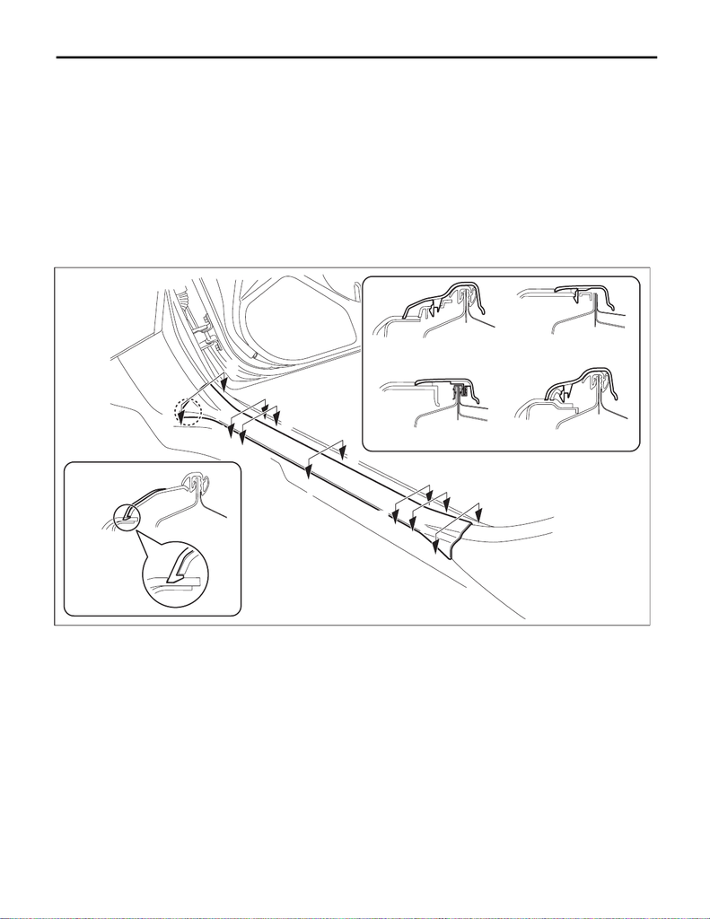

EI-81

Lower Inner Trim

EXTERIOR/INTERIOR TRIM

23.Lower Inner Trim

A: REMOVAL

CAUTION:

• Airbag system satellite safing sensor is located in the lower of the rear seat cushion center. Before

removing the rear seat, refer to “CAUTION” of “General Description” in “AIRBAG SYSTEM” section.

<Ref. to AB-9, CAUTION, General Description.>

• The airbag system is fitted with the airbag power supply. After disconnecting the battery ground

cable, the airbag may operate if you do not wait for 60 seconds before starting the service of airbag

system.

1) Release the claws, and then remove the cover side sill - front INN.

CAUTION:

Do not pull with excessive force. Doing so may damage the claws of the cover side sill - front INN.

EI-04177

C

C

E

E

D

D

B

B

A

A

B-B

D-D

D

D

C

C

D

D

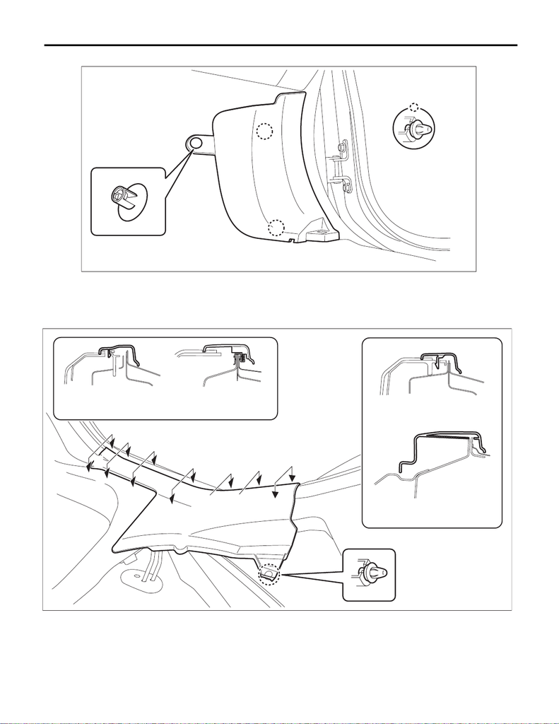

EI-82

Lower Inner Trim

EXTERIOR/INTERIOR TRIM

2) Remove the clips, and remove the cover side sill - front.

3) Remove the rear seat cushion assembly. <Ref. to SE-29, REMOVAL, Rear Seat.>

4) Release the clips and claws, and then remove the cover side sill - rear INN.

CAUTION:

Do not pull with excessive force. Doing so may damage the claws of the cover side sill - rear INN.

EI-03448

EI-03497

A

A

B

B

C-C

D-D

D

D

C

C

C

C

B

B

A-A

B-B

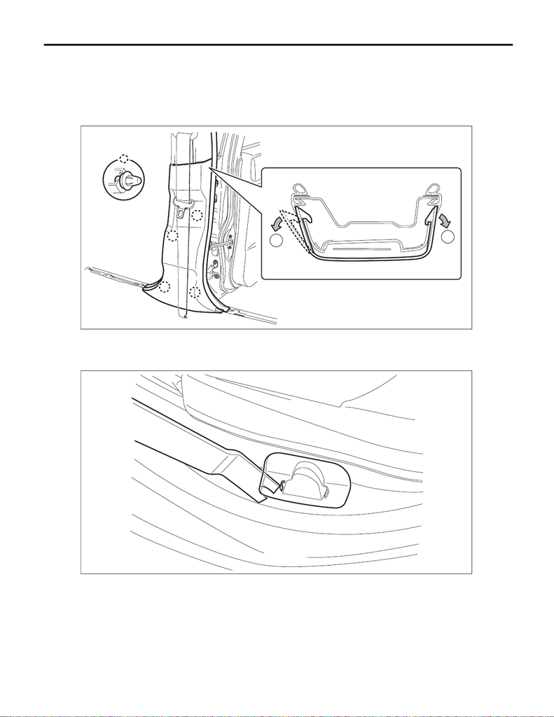

EI-83

Lower Inner Trim

EXTERIOR/INTERIOR TRIM

5) Remove the trim panel - center pillar LWR.

(1) Release the clip by pulling the trim panel - center pillar LWR toward you.

(2) Expand the claws of the trim panel - center pillar LWR outward, and remove it from the trim panel -

center pillar UPR.

CAUTION:

Do not expand the trim panel - center pillar LWR excessively. Doing so may damage the trim.

NOTE:

First release the claw located to the front of the vehicle.

6) Disconnect the claws and remove the cover - catcher.

NOTE:

Remove the cover - catcher by using a plastic remover.

EI-03452

1

2

EI-03528

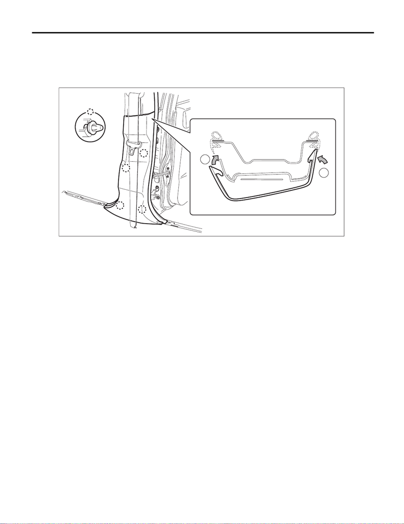

EI-84

Lower Inner Trim

EXTERIOR/INTERIOR TRIM

B: INSTALLATION

1) Install the cover - catcher.

2) Install the trim panel - center pillar LWR.

NOTE:

Assemble the trim panel - center pillar LWR to the trim panel - center pillar UPR securely.

3) Install the cover side sill - rear INN.

4) Install the rear seat cushion assembly.

5) Install the cover side sill - front.

6) Install the cover side sill - front INN.

EI-03453

1

2